# SARIMA Demo

Katie House

June 20, 2018

This demonstration investigate the usage of models with ForecastFramework. For more information on the SARIMA Model itself, check out: https://github.com/reichlab/thai-dengue-district-challenge/blob/master/doc/ff-intro.Rmd.

### Fitting the ForecastFramework SARIMA Model

##### 1. Import packages

First you must import all the required libraries. Note that ForecastFramework doesn’t requre `dplyr` or `ggplot2`, but they will be used to make a figure at the end of the demo.

```r
# Import all Libraries
require(ForecastFramework)
require(R6)
require(forecast)
require(dplyr)
require(ggplot2)

# Source R6 Files
source('models/ContestModel.R')
source('models/SARIMAModel.R')
```

Now it is time to fit your SARIMA Model! ForecastFramework makes this easy.

##### 2. Create new sarima_model Class

In this SARIMA model, simulation is used with `::forecast auto.arima()`. So we must define the number of simulations to use, `nsim`. We also need to define the **seasonal periodicity of our data**, or the `period` parameter. For Dengue forecasting, we know the periodicity is 26, because the data is biweekly. once we define these parameters, they can be passed into the `SARIMAModel()` class generator to create a new `sarima_model` class.

```r
nsim <- 1000 # Number of SARIMA simulations
sarima_model <- SARIMAModel$new(period = 26, nsim = nsim)
```

##### 3. Import Dengue Data

To import data from a local csv, use the `read.csv()` command. In this example, the `date_sick` field is imported as a wrong datatype, so it must be converted to a date value with a couple of transformations. Then, the data is stored as an `IncidenceMatrix()`. An incidence matrix represents spatial time-series data in a matrix with one row per location and one column per time. To do this, another series of transformations are made. IncidenceMatrix is the preferred input for ForecastFramework Models.

```r
# training data for province 10, years 2006 - 2012
dat <- read.csv('data/province-biweek-counts-training.csv')
dat$date_sick <- as.Date(strptime(dat$date_sick,"%m/%d/%Y")) # convert to date values
inc <- IncidenceMatrix$new(1+reshape2::acast(dat,province~date_sick,value.var='cases'))
print(inc$mat[,0:10])
```

```
## 2006-01-01 2006-01-15 2006-01-29 2006-02-12 2006-02-26 2006-03-12
##        266        163        212        114        166        147
## 2006-03-26 2006-04-09 2006-04-23 2006-05-07
##        138        118         75        407
```

##### 3. Fit the Model

Typically, all the provinces in Thailand would be fit separately and have different forecasts. For the scope of this demo, we are only fitting and forecasting **Province 10**. The SARIMAModel method requires the user to specify which province to model, in this case, we are modeling the first (and only) province in the dataset.

```r
# define how many provinces to model
# this demo only has data for one province: Province 10
prov_nums <- 1
nmodels <- length(prov_nums)
sarima_model$fit(inc$subset(rows = prov_nums, mutate = FALSE))
```

### Forecasting with the ForecastFramework SARIMA Model

##### 4. Define the Forecast Model

Before forecasting, you must specify how many periods ahead you would like to forecast. This is defined by the `steps` parameter. Then, you forecast with the `sarima_model$forecast()` method. This model will forecast one year into the future (26 biweeks).

```r
# define how many provinces to model
# this demo only has data for one province: Province 10
steps <- 26 # forecast ahead 26 biweeks
forecast_X <- sarima_model$forecast(steps = steps)
```

##### 5. Format the Forecast Output

Your `$forecast()` method outputs a new object with a variety of methods. For example, to view the output in matrix form execute the following command:

```r
forecast_X$data$mat
```

```
##           1        2       3        4        5        6        7        8
## 10 643.3802 335.2853 241.314 246.4498 203.4687 165.7795 99.31867 201.4191
##           9       10       11       12       13       14       15       16
## 10 218.2934 204.5717 291.7836 339.0986 370.1348 362.6194 452.0522 343.5574
##          17       18       19       20       21       22       23       24
## 10 450.1507 452.5731 321.7004 346.3845 311.0023 292.3865 439.2167 391.8411
##          25       26
## 10 393.9291 164.2607
```

Lets convert the forecast matrix to a data frame in R for easy manipulation:

```r
# converting predictions to a dataframe to use dplyr
preds_df <- data.frame(as.table(t(forecast_X$data$mat)))
```

One limitation to the `forecast_X$data$mat` method is that it does not include the `date_sick` in its output, because the model was trained on a subset of the data. One way to map the forecast to its predicted dates is to create a new data frame with the data from the missing year. Then, we will combine the output in `forecast_X$data` with the correct biweek dates.

```r
# converting predictions to a dataframe to use dplyr
# import testing dataset which has 2013 data
data_X <- read.csv('data/province-biweek-counts-testing.csv')
data_X$date_sick <- strptime(data_X$date_sick,"%m/%d/%Y") # convert to date values
data_X$date_sick <- as.Date(data_X$date_sick)
preds_dates <- data_X %>%
          filter(year == 2013)
# add prediction dates to original forecast
preds_df[["date_sick"]] <-as.Date(preds_dates$date_sick, format = "%d-%m-%Y")
```

Now, we can add the forecast to the `preds_df`

```r
preds_df <- preds_df %>%
   mutate(
      pred_total_cases = as.vector(forecast_X$median()$mat),
      pred_95_lb = as.vector(forecast_X$quantile(0.025)$mat),
      pred_95_ub = as.vector(forecast_X$quantile(0.975)$mat),
      pred_80_lb = as.vector(forecast_X$quantile(0.05)$mat),
      pred_80_ub = as.vector(forecast_X$quantile(0.95)$mat),
      pred_50_lb = as.vector(forecast_X$quantile(0.25)$mat),
      pred_50_ub = as.vector(forecast_X$quantile(0.75)$mat)
   )
print(preds_df)
```

```
##    Var1 Var2      Freq  date_sick pred_total_cases pred_95_lb pred_95_ub
## 1     1   10 643.38024 2013-01-01         400.1421  236.46622   620.8879
## 2     2   10 335.28529 2013-01-15         315.0087  143.51416   545.7738
## 3     3   10 241.31404 2013-01-29         278.1807  100.69180   513.9886
## 4     4   10 246.44984 2013-02-12         262.5791   99.24342   506.0264
## 5     5   10 203.46868 2013-02-26         233.4045   71.80132   497.5700
## 6     6   10 165.77955 2013-03-12         211.5107   57.17203   460.8769
## 7     7   10  99.31867 2013-03-26         181.8441   39.37716   454.7680
## 8     8   10 201.41907 2013-04-09         221.3301   57.33790   512.7123
## 9     9   10 218.29338 2013-04-23         232.1492   62.51912   506.7568
## 10   10   10 204.57175 2013-05-07         252.4420   73.72549   570.9664
## 11   11   10 291.78363 2013-05-21         282.1364   88.39960   596.1519
## 12   12   10 339.09861 2013-06-04         278.3264   87.92464   601.8544
## 13   13   10 370.13483 2013-06-18         326.0625  109.59580   626.6103
## 14   14   10 362.61942 2013-07-02         323.2159  114.27793   636.2850
```

[output cut: 39 more lines]

## Plotting the Output

##### 6. Plot the Forecast Output

Finally, you are able to plot your SARIMA Forecast! Lets use `ggplot2` to create a cool plot.

```r
ggplot() +
  geom_ribbon(
    mapping = aes(x = date_sick, ymin = pred_95_lb, ymax = pred_95_ub),
    fill = "cornflowerblue",
    alpha = 0.2,
    data = preds_df) +
  geom_ribbon(
    mapping = aes(x = date_sick, ymin = pred_80_lb, ymax = pred_80_ub),
    fill = "cornflowerblue",
    alpha = 0.2,
    data = preds_df) +
  geom_ribbon(
    mapping = aes(x = date_sick, ymin = pred_50_lb, ymax = pred_50_ub),
    alpha = 0.2,
    data = preds_df) +
  geom_line(
    mapping = aes(x = date_sick, y = pred_total_cases),
    color = "royalblue",
    size = 2,
    data = preds_df) +
  geom_line(mapping = aes(x = date_sick, y = cases),
            size=0.7,
            data = data_X) +
  xlab("") + ylab("Number of Cases") +
  coord_cartesian(ylim = c(0, 1000))
```

### Bangkok Metropolis SARIMA Forecast

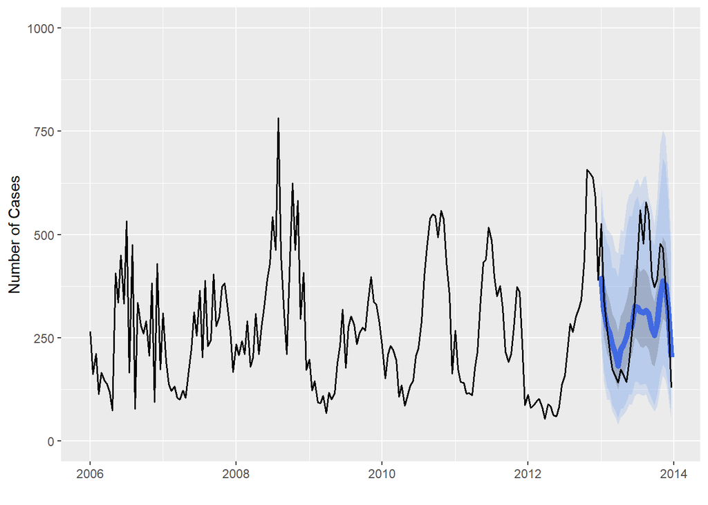